# 波士顿房价预测

机器学习 线性回归（LinearRegression)

# 加载数据集

train_test_split函数用于将矩阵随机划分为训练子集和测试子集，并返回划分好的训练集测试集样本和训练集测试集标签。 StandardScaler----标准化数据，计算训练集的平均值和标准差，以便测试数据集使用相同的变换。

.data加载数据中的所有记录，.target查看数据中的目标值,.shape查看所有记录和目标值的维度 将506个样本13个特征组成的矩阵赋值给变量x,将506个样本1个预测目标值组成的矩阵赋值给变量y。

np.c_是按行连接两个矩阵，就是把两矩阵左右相加，要求行数相等。在numpy中，一个列表虽然是横着表示的，但它是列向量。

DataFrame DataFrame是Python中Pandas库中的一种数据结构，它类似excel，是一种二维表。matlab的矩阵只能放数值型值（当然matlab也可以用cell存放多类型数据），DataFrame的单元格可以存放数值、字符串等。同时DataFrame可以设置列名columns与行名index，可以通过像matlab一样通过位置获取数据也可以通过列名和行名定位。

506条记录，13个特征

```python
import numpy as np
import pandas as pd
import matplotlib.pyplot as plt
from sklearn.datasets import load_boston
from sklearn.cross_validation import train_test_split

boston = load_boston()
print(boston.DESCR)      #关于房价的描述信息
x = boston.data          #数据中所有记录
y = boston.target        #数据中预测目标值
df = pd.DataFrame(data = np.c_[x,y],
                 columns = np.append(boston.feature_names,['MEDV']))
df.head(5)
```

```
Boston House Prices dataset
===========================

Notes
------
Data Set Characteristics:

    :Number of Instances: 506

    :Number of Attributes: 13 numeric/categorical predictive

    :Median Value (attribute 14) is usually the target

    :Attribute Information (in order):
        - CRIM     per capita crime rate by town
        - ZN       proportion of residential land zoned for lots over 25,000 sq.ft.
        - INDUS    proportion of non-retail business acres per town
        - CHAS     Charles River dummy variable (= 1 if tract bounds river; 0 otherwise)
        - NOX      nitric oxides concentration (parts per 10 million)
        - RM       average number of rooms per dwelling
        - AGE      proportion of owner-occupied units built prior to 1940
        - DIS      weighted distances to five Boston employment centres
        - RAD      index of accessibility to radial highways
        - TAX      full-value property-tax rate per $10,000
        - PTRATIO  pupil-teacher ratio by town
        - B        1000(Bk - 0.63)^2 where Bk is the proportion of blacks by town
        - LSTAT    % lower status of the population
        - MEDV     Median value of owner-occupied homes in $1000's

    :Missing Attribute Values: None

    :Creator: Harrison, D. and Rubinfeld, D.L.

This is a copy of UCI ML housing dataset.
http://archive.ics.uci.edu/ml/datasets/Housing


This dataset was taken from the StatLib library which is maintained at Carnegie Mellon University.

The Boston house-price data of Harrison, D. and Rubinfeld, D.L. 'Hedonic
prices and the demand for clean air', J. Environ. Economics & Management,
vol.5, 81-102, 1978.   Used in Belsley, Kuh & Welsch, 'Regression diagnostics
...', Wiley, 1980.   N.B. Various transformations are used in the table on
pages 244-261 of the latter.

The Boston house-price data has been used in many machine learning papers that address regression
problems.

**References**

   - Belsley, Kuh & Welsch, 'Regression diagnostics: Identifying Influential Data and Sources of Collinearity', Wiley, 1980. 244-261.
   - Quinlan,R. (1993). Combining Instance-Based and Model-Based Learning. In Proceedings on the Tenth International Conference of Machine Learning, 236-243, University of Massachusetts, Amherst. Morgan Kaufmann.
   - many more! (see http://archive.ics.uci.edu/ml/datasets/Housing)
```

[output not shown]

# 观察数据集

```python
df.info() #检查缺失
```

```
<class 'pandas.core.frame.DataFrame'>
RangeIndex: 506 entries, 0 to 505
Data columns (total 14 columns):
CRIM       506 non-null float64
ZN         506 non-null float64
INDUS      506 non-null float64
CHAS       506 non-null float64
NOX        506 non-null float64
RM         506 non-null float64
AGE        506 non-null float64
DIS        506 non-null float64
RAD        506 non-null float64
TAX        506 non-null float64
PTRATIO    506 non-null float64
B          506 non-null float64
LSTAT      506 non-null float64
MEDV       506 non-null float64
dtypes: float64(14)
memory usage: 55.4 KB
```

# 显示散点图

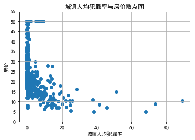

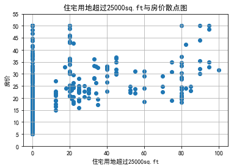

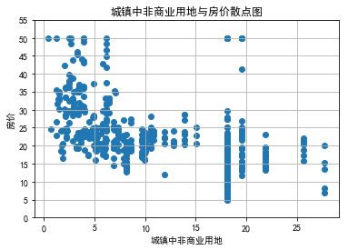

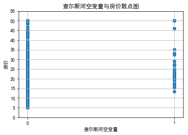

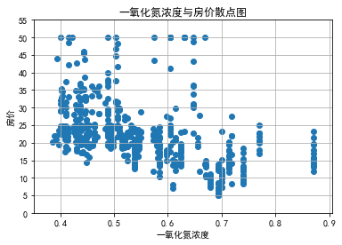

[figure not shown]

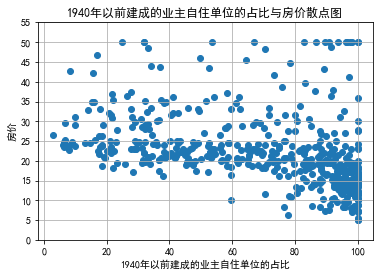

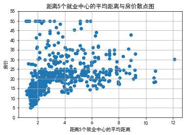

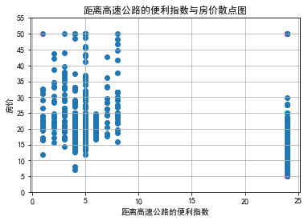

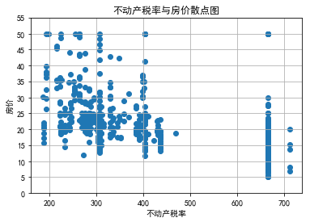

[figure not shown]

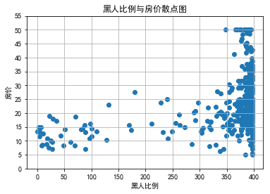

[1 more figures not shown]

```python
plt.rcParams['font.sans-serif']=['SimHei'] #用来正常显示中文标签
plt.rcParams['axes.unicode_minus']=False #用来正常显示负号

#显示散点图
def drawScatter(x, y, xlabel):
    plt.scatter(x, y)
    plt.title('%s与房价散点图' %xlabel)
    plt.xlabel(xlabel)
    plt.ylabel('房价')
    plt.yticks(range(0,60,5)) #刻度
    plt.grid()  #网格
    plt.show()

drawScatter(df['CRIM'], y, '城镇人均犯罪率')
drawScatter(df['ZN'], y, '住宅用地超过25000sq.ft')
drawScatter(df['INDUS'], y, '城镇中非商业用地')
plt.xticks([0,1])
drawScatter(df['CHAS'], y, '查尔斯河空变量')
drawScatter(df['NOX'], y, '一氧化氮浓度')
drawScatter(df['RM'], y, '每栋住宅的房间数')
drawScatter(df['AGE'], y, '1940年以前建成的业主自住单位的占比')
drawScatter(df['DIS'], y, '距离5个就业中心的平均距离')
drawScatter(df['RAD'], y, '距离高速公路的便利指数')
drawScatter(df['TAX'], y, '不动产税率')
drawScatter(df['PTRATIO'], y, '城镇中的教师学生比例')
drawScatter(df['B'], y, '黑人比例')
drawScatter(df['LSTAT'], y, '低收入阶层占比')
```

# 训练模型

根据上面散点图。与房价相关性最强的三个因素分别是，RM(每栋住宅的房间数)，PTRATIO(城镇中的教师学生比例)，LSTAT(低收入阶层占比)。

train_test_split是交叉验证中常用的函数，功能是从样本中随机的按比例选取train data和test data，形式为： X_train,X_test, y_train, y_test = cross_validation.train_test_split(train_data,train_target,test_size=0.4, random_state=0)

参数解释： train_data：所要划分的样本特征集 train_target：所要划分的样本结果 test_size：样本占比，如果是整数的话就是样本的数量 random_state：是随机数的种子。 随机数种子：其实就是该组随机数的编号，在需要重复试验的时候，保证得到一组一样的随机数。比如你每次都填1，其他参数一样的情况下你得到的随机数组是一样的。但填0或不填，每次都会不一样。 随机数的产生取决于种子，随机数和种子之间的关系遵从以下两个规则： 种子不同，产生不同的随机数；种子相同，即使实例不同也产生相同的随机数。

参考《scikit-learn 机器学习常用算法原理及编程实战》 p94

输出训练样本分数和测试分数。

```python
#features = df[['RM', 'PTRATIO', 'LSTAT']]
#x_train,x_test,y_train,y_test = train_test_split(features[['RM', 'PTRATIO', 'LSTAT']],y,test_size = 0.2)

x_train,x_test,y_train,y_test = train_test_split(x,y,test_size = 0.2)

import time
from sklearn.linear_model import LinearRegression
from sklearn.preprocessing import PolynomialFeatures  #多项式拟合
from sklearn.pipeline import Pipeline

def polynomial_model(degree = 1):
    polynomial_features = PolynomialFeatures(degree = degree,include_bias = False)
    linear_regression = LinearRegression(normalize = True)
    pipeline = Pipeline ([("polynomial_features",polynomial_features),("linear_regression",linear_regression)])
    return pipeline


model = polynomial_model(degree = 2) #二阶多项式

start = time.clock()
model.fit(x_train,y_train)

train_score = model.score(x_train,y_train)
cv_score = model.score(x_test,y_test)
print('elaspe:{0:.6f};train_score:{1:0.6f};cv_score:{2:.6f}'.format(time.clock()-start,train_score,cv_score))
```

```
elaspe:0.014940;train_score:0.940777;cv_score:0.808822
```

```
E:\Program Files\Anaconda3\lib\site-packages\ipykernel_launcher.py:20: DeprecationWarning: time.clock has been deprecated in Python 3.3 and will be removed from Python 3.8: use time.perf_counter or time.process_time instead
E:\Program Files\Anaconda3\lib\site-packages\ipykernel_launcher.py:25: DeprecationWarning: time.clock has been deprecated in Python 3.3 and will be removed from Python 3.8: use time.perf_counter or time.process_time instead
```